# Experimentalphysik V

# 6 Leitungselektronen und Bändermodell

- $e^-$ realxieren so schenll, dass das Gitter als statisch angesehen werden kann
- Einelektronnäherung: ein $e^-$ im effektiven Potential aus Gitter und rest Elektronen
- Potential:
  - $V(r) = V_0 = const/\infty, \qquad \forall x,y,z\in{0, L}$
  - $V(r) = V(r+\vec K)$

## 6.1 Freiese Elektronengas / Pauli-Sommerfeld-Modell

- Definierter Impuls des $e^-$ von $\hbar\vec k\Rightarrow e^-$ delokalisiert

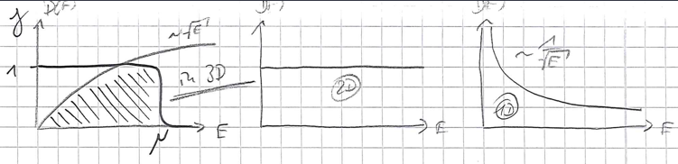

Zustandsbesetzung im $e^-$-Gas Modell

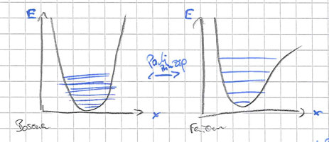

Systemenergie mit und ohne Pauli Prinzip

$$\begin{align}
\mu =& \partial_M(F)|_{T.V}
\end{align}$$

- Fermi-Wellenvektor $k_F$
- Fermi-Energie $E_F=\frac{\hbar^2k_F^2}{2m}$

## 6.2 Wärmekapazität des freien Elektronengases

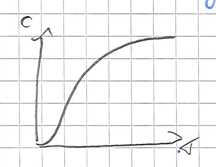

Verlauf

$$\begin{align}
c^{\text{Metall}} = \gamma T+c_{\text{Phonon}} = \gamma T+
\begin{cases}
\beta T^3 & T\leq\leq \Theta_D\\
3R & T\geq\geq \Theta_D
\end{cases}
\end{align}$$

## 6.3 $e^-$ im periodischen Potential

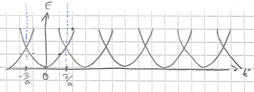

periodisches Potential

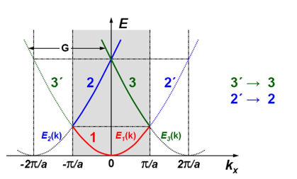

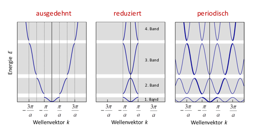

Bandlücken

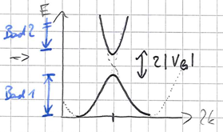

Bänder und Lücken

## 6.4 Dynamik von Bandelektronen

> “Beschleunigungstheorem”

> $$\begin{align}
> \dot{\vec v} = \frac{1}{\hbar^2}\partial_{\vec k}^2(E)\vec F
> \end{align}$$

“effektive Masse”
$$\begin{align}
m^* = h^2\partial_{\vec k}^{-2}(E)
\end{align}$$

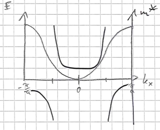

# 7 Supraleitung

## 7.1 Definition

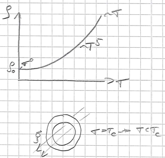

- perfekter Diamagnet:
  $$\begin{align}
  B_i =& \mu_0(H^e+M) = 0 \rightarrow M=-H\\
  \chi_{SI}=&-1, \chi_{CGS}=-\frac{1}{4\pi}
  \end{align}$$

## 7.2 Supraleiter 1. und 2. Art

### 7.2.1 1. Art

- z.B.: Pb, Hg, Al, In

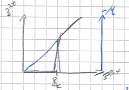

- $B_C(T) = B_0(0)(1-\frac{T^2}{T^2_C})$

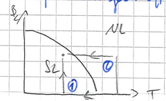

### 7.2.2 2. Art

- z.B.: Legierungen, Hoch-$T_C$-SL, …

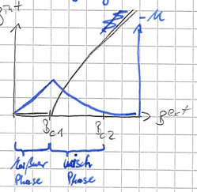

- B-Feld dringt teilw. in SL ein
- es existiert eine Normalleiter-Bereich, mitt Flussquant $\phi_0$

## 7.3 Phänomenologische Beschreibung

> $$\begin{align}
> d_t(\vec j) =& n_{SL}q_{SL}\dot{\vec v} =& \frac{n_{SL}q_{SL}^2}{m_{SL}}\vec E
> \end{align}$$
- $\rightarrow$ London: $E^{-1}\propto \dot n$
> 2. Londonsche Gleichung

> $$\begin{align}
> rot(\vec j) = - \frac{n_{SL}q_{SL}^2}{m_{SL}}\vec B
> \end{align}$$

# 8 Halbleiter

# 9 Dielektrische und optische Eigenschaften von Festkörpern